# Pacific Giant Salamander

Jennifer Truong & Joanne Pham

11/21/2019

## Introduction

The Pacific giant salamander, *Dicamptodon tenebrosus*, is native to the Pacific northwest, and at 13 inches in length, it is one of the largest salamanders in North America (OregonWild). Researchers rely on the salamanders to indicate water quality levels, for these amphibians only live in healthy mountain streams. However, habitat loss through logging and other human activities has raised concerns for the continuation of the species (OregonWild).

Populations of Pacific giant salmanders have been monitored since 1987 (Gregory). A group Oregon State researchers stationed at the HJ Andrews Experimental Forest were already researching the West Slope cutthroat trout, *Onchorhyncus clarki clarki*, at Mack Creek when they decided to include the salamanders in their studies. Each specimen was measured and weighed before release. The number and weight of salamanders were compared between the different areas where they were found, the forest sections (clearcut(CC) and old growth(OG)) and the channel types (channel, pool, and side channel).

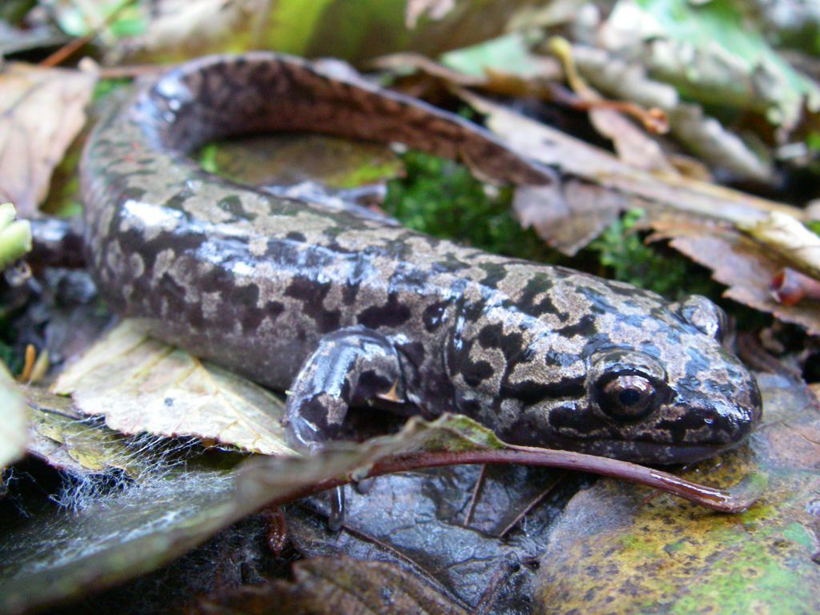

*Figure 1.* *Pacific giant salamander. Credit: [Jeffrey Marsten](https://en.wikipedia.org/wiki/Pacific_giant_salamander#/media/File:Dicamptodon_tenebrosus_2.JPG)*

## Data and Methods

“Old Growth” refers to the 500 year old coniferous forest upstream, while “Clear Cut” refers to the clear-cut section of the forest.

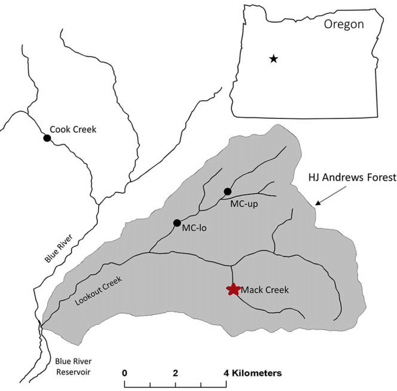

*Figure 2.* *Map of Mack Creek within the HJ Andrews Experimental Forest. Identified with a red star. Credit: [Dana Warren-Oregon State](https://www.researchgate.net/figure/Map-of-study-sites-and-the-HJ-Andrews-Experimental-forest-HJA-Each-dot-represents-a_fig1_314206020)*

## Results

### A. Annual Salamander Counts in Old Growth (OG) and Clear Cut (CC) Sections of Mack Creek

The number of giant salamanders did not change much between the two forest sections. Though more salamanders were found in clearcut (n = 384) than old growth (n = 219) sections in 1987, both soon followed the similar trends of abundance. Salamander counts increased toward 2017, though they seemed to reach their peak for both sections from 2008 to 2012. Then both dipped unil 2015, when populations numbers started rising again into 2017 (CC = 675, OG = 646).

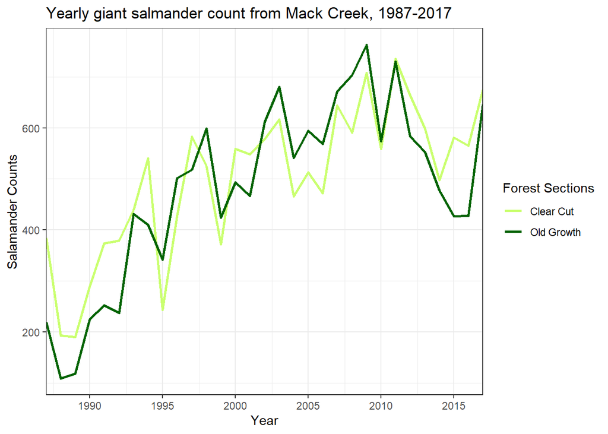

*Figure 3.* *Change in yearly giant salamander abundance between different forest sections(light green: clear cut, dark green: old growth). Both counts increased through the years without many visual differences.*

### B. Salamander Counts by Channel Classification

Just looking populations in the final data collection year, 2017, the proportions of giant salamanders were almost 50% when comparing salamander counts for all channel types across clearcut and original growth sections. This suggests salamanders had almost no preferences between the forest sections, which mirrors the visual results found in Results A. However, there is a large different in salamander counts between the different channel types. There were more giant salamanders in channels (CC = 444, OG = 377) than from the numbers in pools (CC = 101, OG = 129) and side channels (CC = 130, OG = 107) combined.

*Table 1.* *The number of giant salamanders found across different parts of the forest. The proportions were calculated and found at almost 50% between CC and OG sections. However, numbers found in channels greatly exceeded those found in pools or side channels.*

| Proportion of giant salamaders in different channel types and forest sections Channel type | Proportion of giant salamaders in different channel types and forest sections Clear cut | Proportion of giant salamaders in different channel types and forest sections Original growth |
| --- | --- | --- |
| Channel | 444 (54%) | 377 (46%) |
| Pool | 101 (44%) | 129 (56%) |
| Side Channel | 130 (55%) | 107 (45%) |

### C. Hypothesis Testing: Significant Difference in Location?

Based on the substantial differences in salamander numbers between channel types in clear cut and original growth forest sections, the relationship between them was tested to determine association. There is a significant effect of forest condition (CC/OG) on where in the channel salamanders are found (channel/pool/side-channel) ($\chi$<sup>2</sup>(2) = 8.14, *p* = 0.02). The proportions in Table 1 suggest that channel type has stronger effects on salamander locations in forest sections than the other way around.

### D. Comparison of Salamander Weights in OG and CC Sections

First, we will check the distribution of the data.

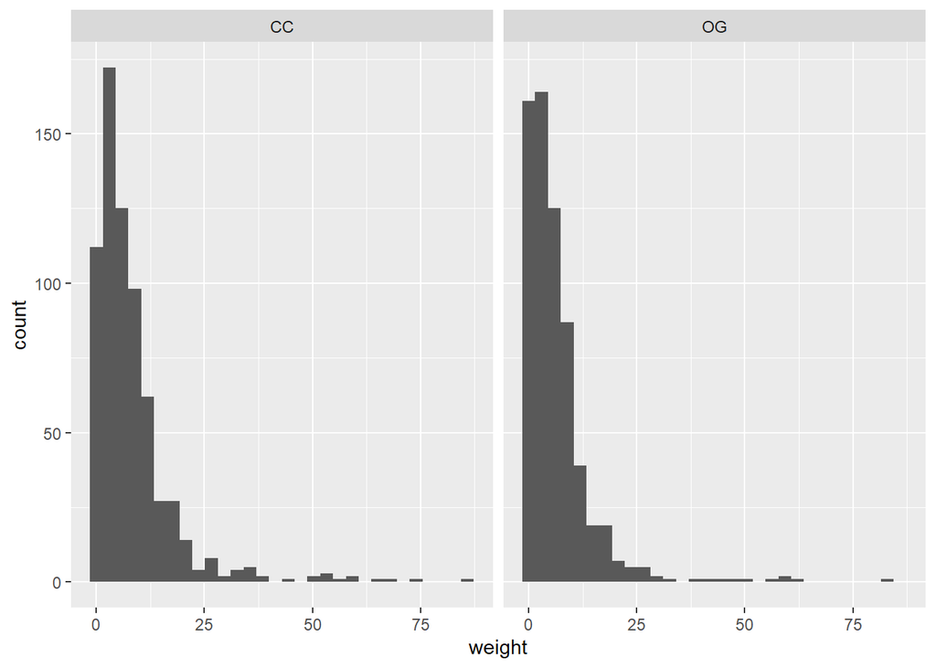

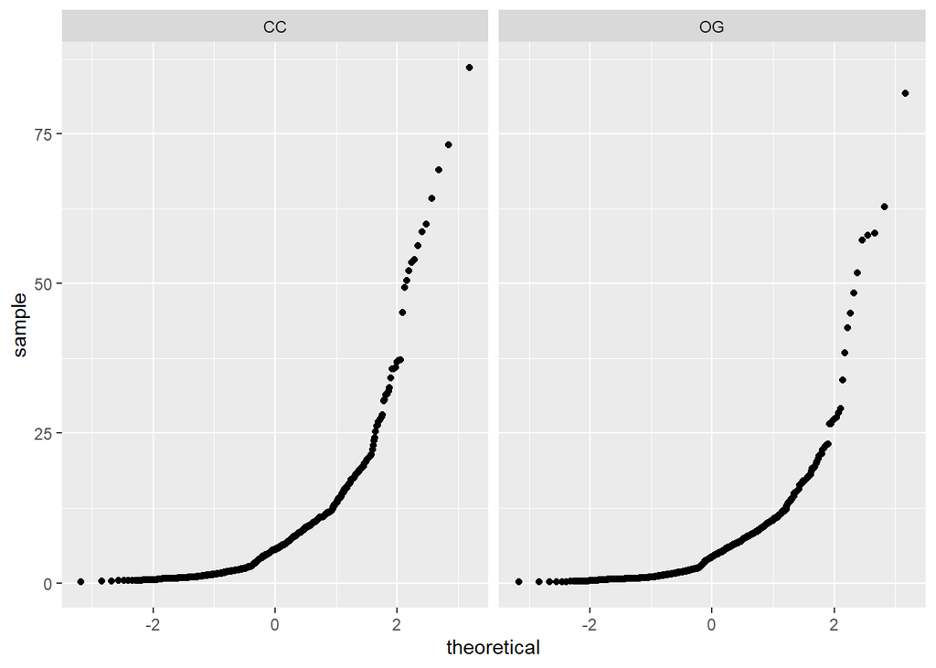

*Figures 4 and 5.* *Histogram and QQ plot of salamanders weights in different forest sections (CC/OG). Visually, neither histogram shows normal distributions of data and the non-linear QQ plots support that analysis.*

The histograms show that the data of salamander weights for both sections are positively skewed, and the qq plots are exponentially rising.

After doing our exploratory analysis, we decide to do an **unpaired, 2 sample two-sided T-test** and a **Mann-Whitney U** to explore salamander weights between the two sections. We assume that the data is unpaired because the two sections are directly connected to each other.

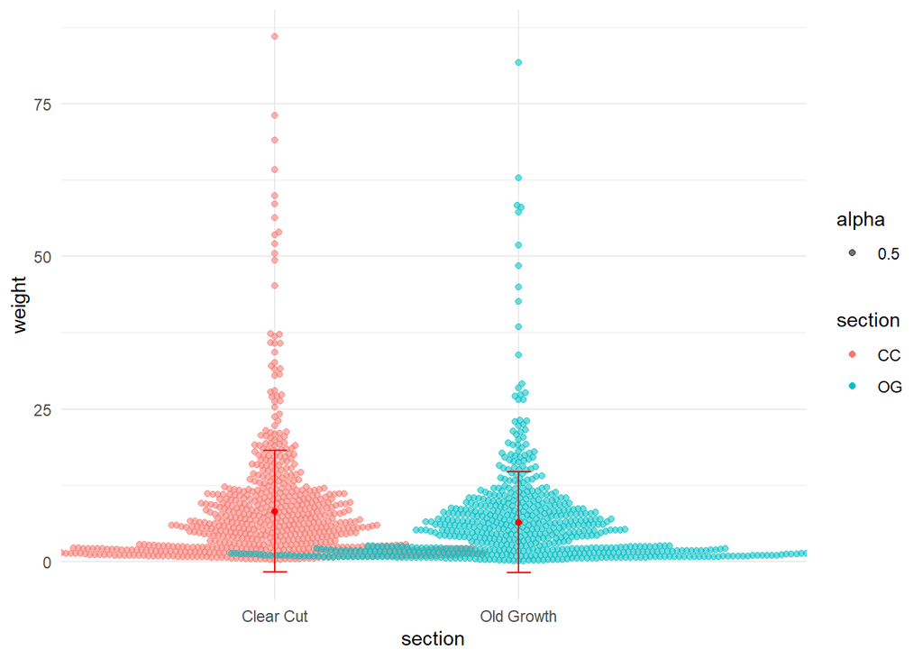

*Figure 6.* *Distribution of salamader weights in clear cut and old growth forest sections. The red dot and lines represent the mean weight and error bar.*

#### Unpaired T-test:

**Null Hypothesis:** The mean salamander weights in both sections are the same.

**Alternative Hypothesis:** The mean salamander weights in both sections are nOT the same.

#### Mann-Whitney U

**Null Hypothesis:** The ranks of the salamander weights are the same between the two sections.

### E. Comparison of Salamander Weights in Pools, Cascades, and Side Channels

Now we will explore the data among the three channel classifications.

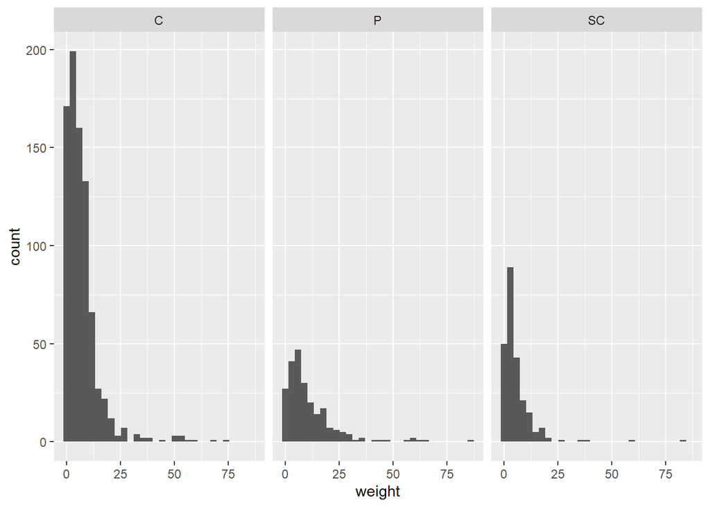

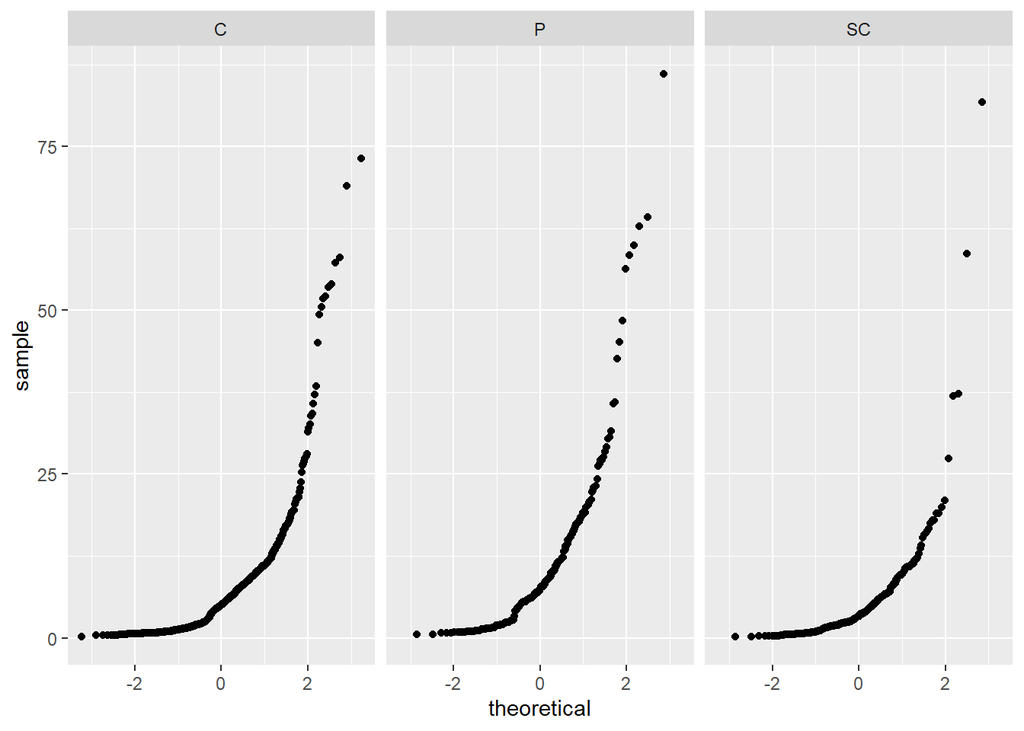

The histograms show that the data of salamander weights for the three channel types are positively skewed, and the qq plots are exponentially rising.

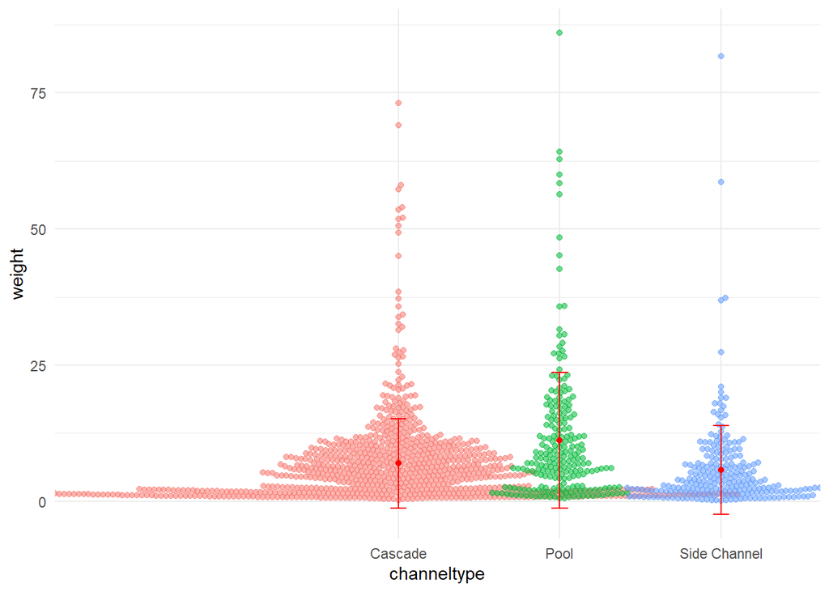

#### One-way ANOVA test

Our random variable is the salamander weight (in grams), and our levels are the three channel classificataions: pools, cascades, and side channels.

**Null Hypothesis:** The mean salamander weights in the three channel types are the same.

Because the data distribution for average salamander weights is positively skewed for both variables (section and channel type), comparing means may not be the best way to compare the groups. Comparing medians through non-parametric tests like the Kruskal-Wallis test would be more preferable in this case.

## Summary

1. Both salamander counts in clear cut and old growth forest conditions increase from 1987 to 2017.
2. There is an association between forest condition and where salamanders are found in channel types, though proportions suggest that the latter variable has a larger influence than the former.

## References

Pacific Giant Salamander. Oregon Wild. https://oregonwild.org/wildlife/pacific-giant-salamander. Accessed 11/28/19.

Gregory S. V. 2016. Aquatic Vertebrate Population Study in Mack Creek, Andrews Experimental Forest, 1987 to present. Environmental Data Initiative. https://doi.org/10.6073/pasta/5de64af9c11579266ef20da2ff32f702. Dataset accessed 11/19/2019.